# Py4Hw User Guide> 10.3 Schematic Visualization Internals

### Next: 10.4 Comparing with other Python based HDLs

The visualization of circuit schematics is implemented from scratch in the framework. It is based on the idea that we have multiple columns. Every circuit is assigned to a column first.

I use a grid where I can place symbols. Only one symbol can be placed in a grid cell. I place the inputs of the circuit in the first column, the instances in the second column and the outputs in the third column.

Then, I analyze the dependencies between symbols. If a symbol input is connected to another symbol output it is placed in the column of the source symbol + 1. To handle loops we do a DFS-based Longest Path layering. outputs are moved to the last column.

Then I create passthrough symbols to avoid having connections between non consecutive columns.

For feedback loops I use a feedback start and feedback stop special symbols and passthrough symbols. Although they represent reverse connections (from right to left) they are connected in forward order to simplify the processing. So feedback stop connects both to the sink symbol and the passthrough chain until it reaches the feedback start. The source symbol of a feedback also connects to this feedback start symbol.

```python
import py4hw
import numpy as np
import pandas as pd
import matplotlib.pyplot as plt
```

```python
def print_matrix():

    mat = sch.symbol_matrix

    nr, nc = mat.shape
    data = np.empty((nr,nc), dtype=object)

    for r in range(nr):
        for c in range(nc):
            sym = mat[r,c]
            if not(sym is None):
                data[r,c] = sym.name
            else:
                data[r,c] = ''

    df = pd.DataFrame(data=data)
    display(df)

    return
```

```python
def print_adjacency_matrix(r_syms, c_syms, am):
    nr = len(r_syms)
    nc = len(c_syms)

    r_names = [item.name for item in r_syms]
    c_names = [item.name for item in c_syms]

    df = pd.DataFrame(data=am, columns=c_names, index=r_names)

    display(df)
```

The schematic object allows to control various things of the visualization process.

The schematic visualization process uses a grid to place symbols like input and output ports and instances. Each grid position can only contain one object.

By analyzing the relations between symbols, we can create an adjacency matrix.

```python
sys = py4hw.HWSystem()
reset = sys.wire('reset')
inc = sys.wire('inc')
q = sys.wire('q', 8)
co = sys.wire('co')

counter = py4hw.ModuloCounter(sys, 'mod7', 7, reset, inc, q, co)
sch = py4hw.Schematic(counter, placeAndRoute=False)
```

### Step 1 Place Inputs

This is the first step, it assigns inputs to the first column of the schematic. For convenience, we assign a name to the block. We actually place the inputs in the grid, no x,y setting. We need to call replaceAsColRow to do it.

Symbols do not know their position at creation, but after calling replaceAsColRow they are assigned pixel coordinates (x,y) and matrix coordinates matching the information from symbol_matrix.

```python
sch.placeInputPorts()
print_matrix()
sch.replaceAsColRow()

sch.createRender()
sch.draw()

print('Input names:', [item.name for item in sch.getNonNets()])
```

[output not shown]

|  | 0 |
| --- | --- |
| 0 | reset |
| 1 | inc |

```
Input names: ['reset', 'inc']
```

### Step 2 Place Instances

All instances of the drawing are placed in the second column.

|  | 0 | 1 |
| --- | --- | --- |
| 0 | reset | one |
| 1 | inc | zero |
| 2 |  | anyreset |
| 3 |  | muxinc |
| 4 |  | muxreset |
| 5 |  | e_add |
| 6 |  | add |
| 7 |  | reg |
| 8 |  | eq6 |

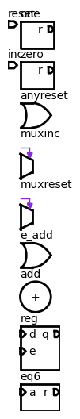

```
Input+Instances names: ['reset', 'inc', 'one', 'zero', 'anyreset', 'muxinc', 'muxreset', 'e_add', 'add', 'reg', 'eq6']
```

```python
sch.placeInstances()
print_matrix()
sch.replaceAsColRow(debug=False)

sch.createRender()
sch.draw()

print('Input+Instances names:', [item.name for item in sch.getNonNets()])
```

### Step 3 Place outputs

The outputs are placed in the third column

|  | 0 | 1 | 2 |
| --- | --- | --- | --- |
| 0 | reset | one | q |
| 1 | inc | zero | carryout |
| 2 |  | anyreset |  |
| 3 |  | muxinc |  |
| 4 |  | muxreset |  |
| 5 |  | e_add |  |
| 6 |  | add |  |
| 7 |  | reg |  |
| 8 |  | eq6 |  |

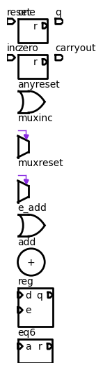

```
Inputs+Instances+Outputs names: ['reset', 'inc', 'one', 'zero', 'anyreset', 'muxinc', 'muxreset', 'e_add', 'add', 'reg', 'eq6', 'q', 'carryout']
```

```python
sch.placeOutputPorts()
print_matrix()

sch.replaceAsColRow()

sch.createRender()
sch.draw()
print('Inputs+Instances+Outputs names:', [item.name for item in sch.getNonNets()])
```

### Step 4 Column Assignment

This stage assigns a column (layer) to each symbol based on data-dependency depth in the circuit graph and then maps symbols to matrix coordinates.

The circuit is modeled as a directed graph where edges represent signal dependencies. Inputs are fixed in column 0. Each logic instance is assigned to a column equal to one plus the maximum column of its source dependencies (i.e., DFS-based longest-path layering). Feedback loops are explicitly handled via cycle detection to prevent infinite recursion during depth computation.

Outputs are placed in a final column after all logic instances.

Once column indices are determined, symbols are ordered within each column and placed into symbol_matrix[row, col], where the row corresponds to the symbol’s position within its column and the column corresponds to its computed dependency level.

|  | 0 | 1 | 2 | 3 | 4 | 5 | 6 | 7 | 8 |
| --- | --- | --- | --- | --- | --- | --- | --- | --- | --- |
| 0 | reset | one | add | muxinc | muxreset | reg | eq6 | anyreset | q |
| 1 | inc | zero |  |  |  |  |  |  | carryout |
| 2 |  | e_add |  |  |  |  |  |  |  |

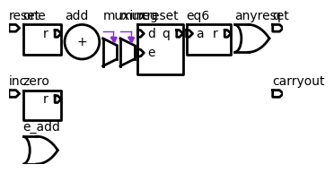

```python
sch.columnAssignment()

print_matrix()
sch.replaceAsColRow()
sch.createRender()
sch.draw()
```

### Step 5 Move Right

Some sources are placed far from the sinks because the sinks have other sources in righter columns. We can reduce this distance by placing this far sources to the immediate column before the sink.

|  | 0 | 1 | 2 | 3 | 4 | 5 | 6 | 7 | 8 |
| --- | --- | --- | --- | --- | --- | --- | --- | --- | --- |
| 0 | reset | one | add | muxinc | muxreset | reg | eq6 | anyreset | q |
| 1 | inc |  |  | zero |  |  |  |  | carryout |
| 2 |  |  |  |  | e_add |  |  |  |  |

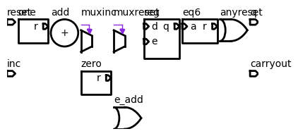

```python
sch.moveToRightColumn(debug=False)
print_matrix()
sch.replaceAsColRow()

sch.createRender()
sch.draw()
```

### Step 6 Remove empty columns

The moving operation could have created empty columns, we could remove them

```python
sch.removeEmptyColumns()
sch.replaceAsColRow()
print_matrix()
```

|  | 0 | 1 | 2 | 3 | 4 | 5 | 6 | 7 | 8 |
| --- | --- | --- | --- | --- | --- | --- | --- | --- | --- |
| 0 | reset | one | add | muxinc | muxreset | reg | eq6 | anyreset | q |
| 1 | inc |  |  | zero |  |  |  |  | carryout |
| 2 |  |  |  |  | e_add |  |  |  |  |

### Step 7 Net creation

Nets are objects that connect elements.

Nets are point to point connections. They collect a source symbol with a sink symbol. Symbols can have multiple ports, so nets also collect the ports of the connection endpoints. Nets are later routed to be rendered into polygons

```
reset --> anyreset
eq6 --> anyreset
inc --> muxinc
reg --> muxinc
add --> muxinc
anyreset --> muxreset
muxinc --> muxreset
zero --> muxreset
reset --> e_add
inc --> e_add
reg --> add
one --> add
muxreset --> reg
e_add --> reg
reg --> eq6
reg --> q
eq6 --> carryout
```

```
<py4hw.schematic.MatplotlibRender at 0x13f2aa9fe90>
```

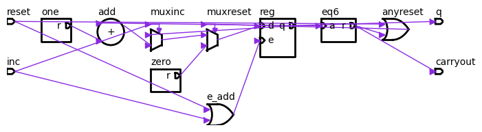

```python
sch.createNets()

for net in sch.nets:
    source = net.source
    sink = net.sink
    print(source.name, '-->', sink.name)

sch.CELL_MARGIN_HORIZONTAL = 50
sch.replaceAsColRow()
sch.routeNets(mode='direct')
sch.createRender()
sch.drawAll(debug=True)
```

### Identify feedback loops

We need to find feedback loops

```python
syms = sch.findFeedbackSinkSymbols()
print('Feedback sinks', [sym.name for sym in syms])

syms = sch.findFeedbackSourceSymbols()
print('Feedback sources', [sym.name for sym in syms])
```

```
Feedback sinks ['muxinc', 'muxreset', 'add']
Feedback sources ['reg', 'anyreset', 'reg']
```

### Create empty columns after beedback sources and before feedback sinks

Since elements that have a connection to the left of the diagonal are feedback loops, we indentify the sink symbols of this elements (the ones in the columns) and create an empty column in the symbol matrix before them

```python
sch.insertColumnsAfterFeedback()
sch.insertColumnsBeforeFeedback()
sch.replaceAsColRow()
print_matrix()
```

|  | 0 | 1 | 2 | 3 | 4 | 5 | 6 | 7 | 8 | 9 | 10 | 11 | 12 | 13 |
| --- | --- | --- | --- | --- | --- | --- | --- | --- | --- | --- | --- | --- | --- | --- |
| 0 | reset | one |  | add |  | muxinc |  | muxreset | reg |  | eq6 | anyreset |  | q |
| 1 | inc |  |  |  |  | zero |  |  |  |  |  |  |  | carryout |
| 2 |  |  |  |  |  |  |  | e_add |  |  |  |  |  |  |

### Step 8 Passthrough creation

We create elements so that connections are never connecting elements from non-contiguous levels. An exception are feedback loops.

The idea is that we can have

```
         level 1      level 2    level 3
          +---+                  +---+
       +->| A | ---+------------>| B |
       |  +---+    |             +---+
       |           |  +---+
       |           +->| C |--+
       |              +---+  |
       +---------------------+
```

and we convert it to

```
level 1   level 2      level 3      level 4
 +---+     +---+       +-----+      +---+
 |Fe |--+->| A | ---+--| pt1 |----->| B |
 +---+  |  +---+    |  +-----+      +---+
        |           |  +---+        +----+
        |           +->| C |------->| Fs |
        |              +---+        |    |
        |   +-----+    +-----+      |    |
        +---| pt1 |----| pt1 |----->|    |
            +-----+    +---+        +----+
```

then, some connections no longer have information about the connecting endpoint. Is that a problem ?

To make it simple passthrough channels should insert a row in the symbol matrix just below the block point.

Feedback channels should insert a row at the bottom of the symbol matrix.

```
Inserting passtrought from  reset to e_add
row 0 not free
Inserting passtrought from  reset to anyreset
row 0 not free
Inserting passtrought from  inc to muxinc
row 3 not free
Inserting passtrought from  inc to e_add
row 3 not free
Inserting passtrought from  one to add
row 0 not free
Inserting passtrought from  add to muxinc
row 0 not free
Inserting passtrought from  muxinc to muxreset
row 0 not free
Inserting passtrought from  zero to muxreset
row 6 not free
Inserting passtrought from  reg to q
row 0 not free
Inserting feedback from  reg to muxinc
Inserting passtrought from  reg to eq6
row 0 not free
Inserting feedback from  reg to add
Inserting passtrought from  eq6 to carryout
row 0 not free
Inserting feedback from  anyreset to muxreset
```

|  | 0 | 1 | 2 | 3 | 4 | 5 | 6 | 7 | 8 | 9 | 10 | 11 | 12 | 13 |
| --- | --- | --- | --- | --- | --- | --- | --- | --- | --- | --- | --- | --- | --- | --- |
| 0 | reset | one | fZ48 | add | fZ39 | muxinc | fZ57 | muxreset | reg |  | eq6 | anyreset |  | q |
| 1 |  |  |  |  |  |  |  |  |  |  |  | pt49 | pt50 |  |
| 2 |  |  |  |  |  |  |  |  |  | pt40 |  |  |  |  |
| 3 |  |  |  |  |  |  |  |  |  | pt30 | pt31 | pt32 | pt33 |  |
| 4 |  |  |  |  |  |  | pt28 |  |  |  |  |  |  |  |
| 5 |  |  |  |  | pt27 |  |  |  |  |  |  |  |  |  |
| 6 |  |  | pt26 |  |  |  |  |  |  |  |  |  |  |  |
| 7 |  | pt6 | pt7 | pt8 | pt9 | pt10 | pt11 | pt12 | pt13 | pt14 | pt15 |  |  |  |
| 8 |  | pt0 | pt1 | pt2 | pt3 | pt4 | pt5 |  |  |  |  |  |  |  |
| 9 | inc |  |  |  |  | zero |  |  |  |  |  |  |  | carryout |
| 10 |  |  |  |  |  |  | pt29 |  |  |  |  |  |  |  |
| 11 |  | pt20 | pt21 | pt22 | pt23 | pt24 | pt25 |  |  |  |  |  |  |  |
| 12 |  | pt16 | pt17 | pt18 | pt19 |  |  |  |  |  |  |  |  |  |
| 13 |  |  |  |  |  |  |  | e_add |  |  |  |  |  |  |
| 14 |  |  |  |  |  | pt38 | pt37 | pt36 | pt35 | fA34 |  |  |  |  |
| 15 |  |  |  | pt47 | pt46 | pt45 | pt44 | pt43 | pt42 | fA41 |  |  |  |  |
| 16 |  |  |  |  |  |  |  | pt56 | pt55 | pt54 | pt53 | pt52 | fA51 |  |

```
<py4hw.schematic.MatplotlibRender at 0x13f2ac37cd0>
```

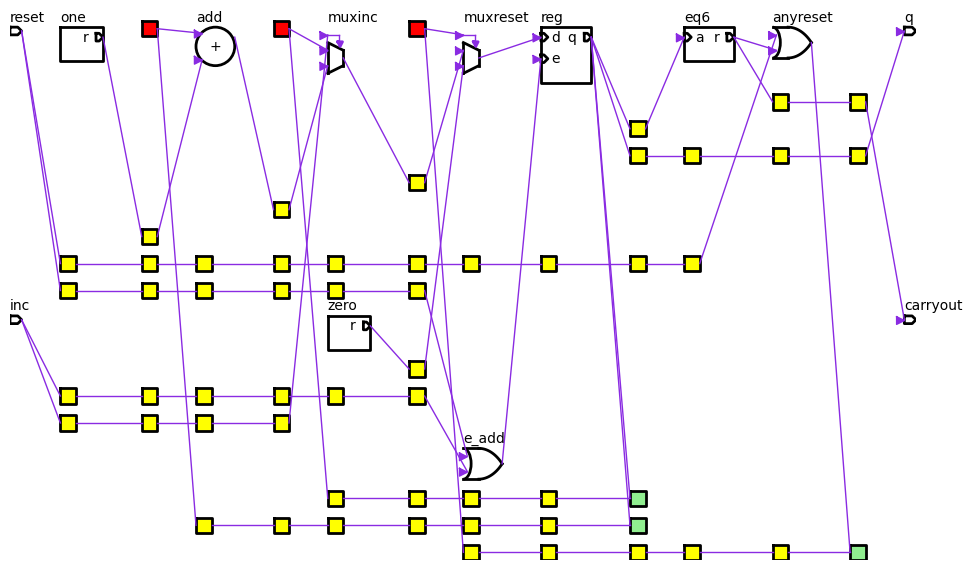

```python
sch.passthroughCreation()
sch.replaceAsColRow()

print()
print()
print_matrix()

sch.replaceAsColRow()
sch.routeNets(mode='direct')
sch.createRender()
sch.drawAll(debug=True)
```

```python
print_matrix()
```

|  | 0 | 1 | 2 | 3 | 4 | 5 | 6 | 7 | 8 | 9 | 10 | 11 | 12 | 13 |
| --- | --- | --- | --- | --- | --- | --- | --- | --- | --- | --- | --- | --- | --- | --- |
| 0 | reset | one | fZ48 | add | fZ39 | muxinc | fZ57 | muxreset | reg |  | eq6 | anyreset |  | q |
| 1 |  |  |  |  |  |  |  |  |  |  |  | pt49 | pt50 |  |
| 2 |  |  |  |  |  |  |  |  |  | pt40 |  |  |  |  |
| 3 |  |  |  |  |  |  |  |  |  | pt30 | pt31 | pt32 | pt33 |  |
| 4 |  |  |  |  |  |  | pt28 |  |  |  |  |  |  |  |
| 5 |  |  |  |  | pt27 |  |  |  |  |  |  |  |  |  |
| 6 |  |  | pt26 |  |  |  |  |  |  |  |  |  |  |  |
| 7 |  | pt6 | pt7 | pt8 | pt9 | pt10 | pt11 | pt12 | pt13 | pt14 | pt15 |  |  |  |
| 8 |  | pt0 | pt1 | pt2 | pt3 | pt4 | pt5 |  |  |  |  |  |  |  |
| 9 | inc |  |  |  |  | zero |  |  |  |  |  |  |  | carryout |
| 10 |  |  |  |  |  |  | pt29 |  |  |  |  |  |  |  |
| 11 |  | pt20 | pt21 | pt22 | pt23 | pt24 | pt25 |  |  |  |  |  |  |  |
| 12 |  | pt16 | pt17 | pt18 | pt19 |  |  |  |  |  |  |  |  |  |
| 13 |  |  |  |  |  |  |  | e_add |  |  |  |  |  |  |
| 14 |  |  |  |  |  | pt38 | pt37 | pt36 | pt35 | fA34 |  |  |  |  |
| 15 |  |  |  | pt47 | pt46 | pt45 | pt44 | pt43 | pt42 | fA41 |  |  |  |  |
| 16 |  |  |  |  |  |  |  | pt56 | pt55 | pt54 | pt53 | pt52 | fA51 |  |

### Identify Mergeable Passthrough Symbols

If a symbol is connected to two (or more) passthrough symbols in the same level that are in close row, we can merge the passthrough symbol.

Two mergeable passthrough symbols have the following setup

```
 A ---> pt1 ---> B
   ---> pt2 ---> C
```

than can be converted into

```
 A ---> pt1 ---> B
            ---> C
```

In this case we remove pt2. To do it, we detect that A has two sinks that are passthrough, we remove the net from A to pt2, remove pt2, and change the source of the last net to pt1.

or this one

```
A --> pt1 --> C
B --> pt2 -->
```

that can be converted into

```
A --> pt1 --> C
B -->
```

In this case we remove pt2. To do it, we detect that C has two sources that are passthrough, we remove the net from pt2 to C, remove pt2, and change the sink of the net from B to pt1.

We have an additional case with feedback start symbols

```
A --> fA1
A --> fA2
pt1 --> fA1
pt2 --> fA2
```

that could be converted into

```
A --> fA1
pt1 --> fA1
pt2 --> fA1
```

In this case we remove fA2. To do it, we detect that A has two sinks that are feedback starts. If both feedback starts are in consecutive rows we remove the second one, remove the nets pointing to it, and change the sink of the nets pointing to it for the first node.

```
Trying to merge sinks
Merging Sink: pt6 with pt0 in  8 1

Merging Sink: pt20 with pt16 in  12 1

Merging Sink: pt40 with pt30 in  3 9

Trying to merge feedback starts
pt1_fA1_net =  pt35 --> fA34
A_fA1_net   =  reg --> fA34
A_fA2_net   =  reg --> fA41
pt1_fA2_net  =  pt42 --> fA41
Merging Feedback: pt42 --> fA34

pt1_fA1_net =  pt42 --> fA34
A_fA1_net   =  reg --> fA34
pt1_fA1_net =  pt52 --> fA51
A_fA1_net   =  anyreset --> fA51
Trying to merge sources
Merging Source: pt42 15 8 True
Trying to merge sinks
Merging Sink: pt7 with pt1 in  8 2

Merging Sink: pt21 with pt17 in  12 2

Trying to merge feedback starts
pt1_fA1_net =  pt35 --> fA34
A_fA1_net   =  reg --> fA34
pt1_fA1_net =  pt52 --> fA51
A_fA1_net   =  anyreset --> fA51
Trying to merge sources
Merging Source: pt43 15 7 True
Trying to merge sinks
Merging Sink: pt8 with pt2 in  8 3

Merging Sink: pt22 with pt18 in  12 3

Trying to merge feedback starts
pt1_fA1_net =  pt35 --> fA34
A_fA1_net   =  reg --> fA34
```

[output cut: 26 more lines]

```
Merging Sink: pt11 with pt5 in  8 6

Trying to merge feedback starts
pt1_fA1_net =  pt35 --> fA34
A_fA1_net   =  reg --> fA34
pt1_fA1_net =  pt52 --> fA51
A_fA1_net   =  anyreset --> fA51
Trying to merge sources
Trying to merge sinks
Trying to merge feedback starts
pt1_fA1_net =  pt35 --> fA34
A_fA1_net   =  reg --> fA34
pt1_fA1_net =  pt52 --> fA51
A_fA1_net   =  anyreset --> fA51
Trying to merge sources
```

```
<py4hw.schematic.MatplotlibRender at 0x13f2ac55c10>
```

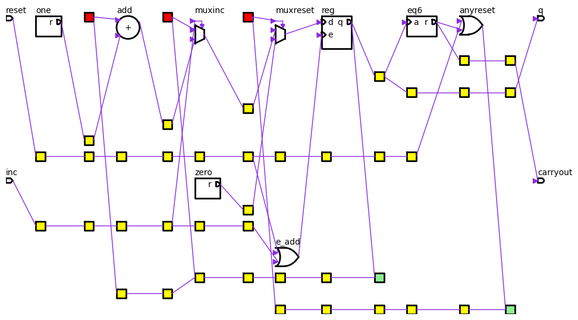

```python
sch.mergeVirtualSymbols(debug=True)
sch.replaceAsColRow()
sch.routeNets(mode='direct')
sch.createRender()
sch.drawAll(debug=True)
```

### Move inputs and outputs

```python
def moveCloseRow(self, sym, dstr):
    nr, nc = self.symbol_matrix.shape

    if (sym.r == dstr):
        return

    freer = [r for r in range(nr) if self.symbol_matrix[r, sym.c] is None] # free rows
    freer.sort(key=lambda r: abs(dstr - r))

    if len(freer) == 0:
        return

    # Move it to the free row
    self.symbol_matrix[sym.r, sym.c] = None
    self.symbol_matrix[freer[0], sym.c] = sym
    sym.r = freer[0]

def moveUpToRow(self, sym, dstr):
    nr, nc = self.symbol_matrix.shape

    if (sym.r == dstr):
        return

    freer = [r for r in range(sym.r+1, dstr+1) if self.symbol_matrix[r, sym.c] is None] # free rows
    freer.sort(key=lambda r: abs(dstr - r))

    if len(freer) == 0:
        return

    # Move it to the free row
    self.symbol_matrix[sym.r, sym.c] = None
    self.symbol_matrix[freer[0], sym.c] = sym
    sym.r = freer[0]
```

```
moving reset to 7
moving inc to 11
moving q to 3
moving carryout to 1
```

```
<py4hw.schematic.MatplotlibRender at 0x13f2acdc450>
```

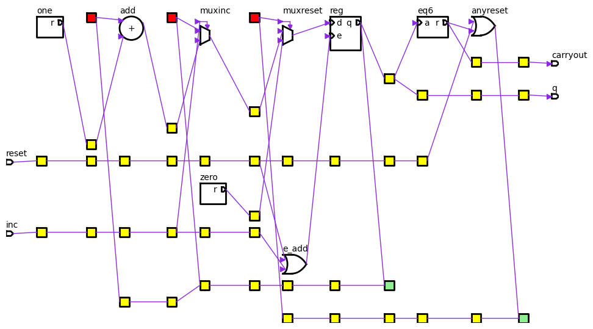

```python
nr, nc = sch.symbol_matrix.shape

tomove = []

# move inputs
for r in range(nr):
    sym = sch.symbol_matrix[r, 0]

    if (sym is None):
        continue

    avgr = int(np.mean([sym.r for sym in sch.getSinkSymbols(sym)]))

    tomove.append((sym, avgr))
# move outputs
for r in range(nr):
    sym = sch.symbol_matrix[r, nc-1]

    if (sym is None):
        continue

    avgr = int(np.mean([sym.r for sym in sch.getSourceSymbols(sym)]))

    tomove.append((sym, avgr))

for sym, avgr in tomove:
    print('moving', sym.name, 'to', avgr)

    moveCloseRow(sch, sym, avgr)

sch.replaceAsColRow()
sch.routeNets(mode='direct')
sch.createRender()
sch.drawAll(debug=True)
```

### Move instances down

```
<py4hw.schematic.MatplotlibRender at 0x13f2ac23790>
```

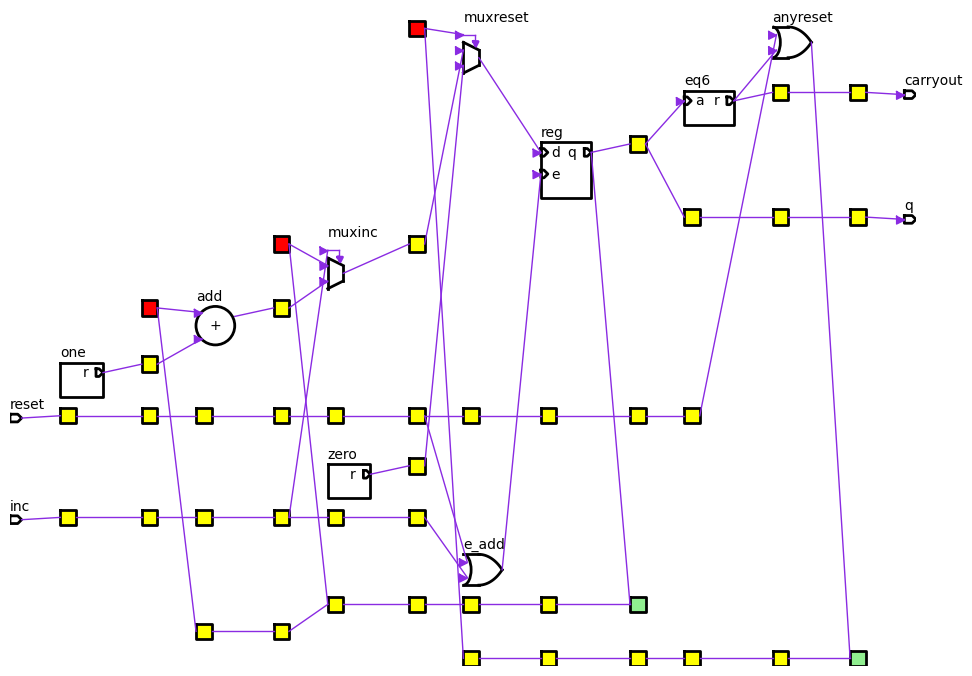

```python
for net in sch.getNets():
    if not(isinstance(net.source, py4hw.VirtualSymbol)) and isinstance(net.sink, py4hw.PassthroughSymbol):
        moveUpToRow(sch, net.source, net.sink.r)

for net in sch.getNets():
    if not(isinstance(net.sink, py4hw.VirtualSymbol)) and isinstance(net.source, py4hw.FeedbackStopSymbol):
        moveUpToRow(sch, net.source, net.sink.r)

sch.replaceAsColRow()
sch.routeNets(mode='direct')
sch.createRender()
sch.drawAll(debug=True)
```

### Check what happened with nets

Nets were created also

```python
for net in sch.nets:
    source = net.source
    sourcePort = net.sourcePort
    sink = net.sink
    sinkPort = net.sinkPort

    if (sourcePort is not None):
        sourcePort = f'[{sourcePort.name}]'
    else:
        sourcePort = ''

    if (sinkPort is not None):
        sinkPort = f'[{sinkPort.name}]'
    else:
        sinkPort = ''

    print(source.name, sourcePort, '-->', sink.name, sinkPort)
```

```
eq6 [r] --> anyreset [b]
muxreset [r] --> reg [d]
e_add [r] --> reg [e]
pt11  --> e_add [a]
reset [reset] --> pt6
pt6  --> pt7
pt7  --> pt8
pt8  --> pt9
pt9  --> pt10
pt10  --> pt11
pt11  --> pt12
pt12  --> pt13
pt13  --> pt14
pt14  --> pt15
pt15  --> anyreset [a]
pt23  --> muxinc [sel]
inc [inc] --> pt20
pt20  --> pt21
pt21  --> pt22
pt22  --> pt23
pt23  --> pt24
pt24  --> pt25
pt25  --> e_add [b]
one [r] --> pt26
pt26  --> add [b]
add [r] --> pt27
pt27  --> muxinc [sel1]
muxinc [r] --> pt28
pt28  --> muxreset [sel0]
zero [r] --> pt29
pt29  --> muxreset [sel1]
pt40  --> pt31
pt31  --> pt32
pt32  --> pt33
pt33  --> q [q]
reg [q] --> fA34
pt35  --> fA34
pt36  --> pt35
pt37  --> pt36
pt38  --> pt37
fZ39  --> pt38
fZ39  --> muxinc [sel0]
reg [q] --> pt40
pt40  --> eq6 [a]
pt46  --> pt38
pt47  --> pt46
fZ48  --> pt47
fZ48  --> add [a]
eq6 [r] --> pt49
pt49  --> pt50
pt50  --> carryout [carryout]
anyreset [r] --> fA51
pt52  --> fA51
pt53  --> pt52
pt54  --> pt53
pt55  --> pt54
pt56  --> pt55
fZ57  --> pt56
fZ57  --> muxreset [sel]
```

```python
am = sch.getAdjacencyMatrix()
syms = sch.getNonNets()
print_adjacency_matrix(syms, syms, am)
```

|  | reset | inc | one | pt6 | pt20 | fZ48 | pt26 | pt7 | pt21 | add | ... | pt53 | anyreset | pt49 | pt32 | pt52 | pt50 | pt33 | fA51 | carryout | q |
| --- | --- | --- | --- | --- | --- | --- | --- | --- | --- | --- | --- | --- | --- | --- | --- | --- | --- | --- | --- | --- | --- |
| reset | 0 | 0 | 0 | 1 | 0 | 0 | 0 | 0 | 0 | 0 | ... | 0 | 0 | 0 | 0 | 0 | 0 | 0 | 0 | 0 | 0 |
| inc | 0 | 0 | 0 | 0 | 1 | 0 | 0 | 0 | 0 | 0 | ... | 0 | 0 | 0 | 0 | 0 | 0 | 0 | 0 | 0 | 0 |
| one | 0 | 0 | 0 | 0 | 0 | 0 | 1 | 0 | 0 | 0 | ... | 0 | 0 | 0 | 0 | 0 | 0 | 0 | 0 | 0 | 0 |
| pt6 | 0 | 0 | 0 | 0 | 0 | 0 | 0 | 1 | 0 | 0 | ... | 0 | 0 | 0 | 0 | 0 | 0 | 0 | 0 | 0 | 0 |
| pt20 | 0 | 0 | 0 | 0 | 0 | 0 | 0 | 0 | 1 | 0 | ... | 0 | 0 | 0 | 0 | 0 | 0 | 0 | 0 | 0 | 0 |
| fZ48 | 0 | 0 | 0 | 0 | 0 | 0 | 0 | 0 | 0 | 1 | ... | 0 | 0 | 0 | 0 | 0 | 0 | 0 | 0 | 0 | 0 |
| pt26 | 0 | 0 | 0 | 0 | 0 | 0 | 0 | 0 | 0 | 1 | ... | 0 | 0 | 0 | 0 | 0 | 0 | 0 | 0 | 0 | 0 |
| pt7 | 0 | 0 | 0 | 0 | 0 | 0 | 0 | 0 | 0 | 0 | ... | 0 | 0 | 0 | 0 | 0 | 0 | 0 | 0 | 0 | 0 |
| pt21 | 0 | 0 | 0 | 0 | 0 | 0 | 0 | 0 | 0 | 0 | ... | 0 | 0 | 0 | 0 | 0 | 0 | 0 | 0 | 0 | 0 |
| add | 0 | 0 | 0 | 0 | 0 | 0 | 0 | 0 | 0 | 0 | ... | 0 | 0 | 0 | 0 | 0 | 0 | 0 | 0 | 0 | 0 |
| pt8 | 0 | 0 | 0 | 0 | 0 | 0 | 0 | 0 | 0 | 0 | ... | 0 | 0 | 0 | 0 | 0 | 0 | 0 | 0 | 0 | 0 |
| pt22 | 0 | 0 | 0 | 0 | 0 | 0 | 0 | 0 | 0 | 0 | ... | 0 | 0 | 0 | 0 | 0 | 0 | 0 | 0 | 0 | 0 |
| pt47 | 0 | 0 | 0 | 0 | 0 | 0 | 0 | 0 | 0 | 0 | ... | 0 | 0 | 0 | 0 | 0 | 0 | 0 | 0 | 0 | 0 |
| fZ39 | 0 | 0 | 0 | 0 | 0 | 0 | 0 | 0 | 0 | 0 | ... | 0 | 0 | 0 | 0 | 0 | 0 | 0 | 0 | 0 | 0 |
| pt27 | 0 | 0 | 0 | 0 | 0 | 0 | 0 | 0 | 0 | 0 | ... | 0 | 0 | 0 | 0 | 0 | 0 | 0 | 0 | 0 | 0 |
| pt9 | 0 | 0 | 0 | 0 | 0 | 0 | 0 | 0 | 0 | 0 | ... | 0 | 0 | 0 | 0 | 0 | 0 | 0 | 0 | 0 | 0 |
| pt23 | 0 | 0 | 0 | 0 | 0 | 0 | 0 | 0 | 0 | 0 | ... | 0 | 0 | 0 | 0 | 0 | 0 | 0 | 0 | 0 | 0 |
| pt46 | 0 | 0 | 0 | 0 | 0 | 0 | 0 | 0 | 0 | 0 | ... | 0 | 0 | 0 | 0 | 0 | 0 | 0 | 0 | 0 | 0 |
| muxinc | 0 | 0 | 0 | 0 | 0 | 0 | 0 | 0 | 0 | 0 | ... | 0 | 0 | 0 | 0 | 0 | 0 | 0 | 0 | 0 | 0 |
| pt10 | 0 | 0 | 0 | 0 | 0 | 0 | 0 | 0 | 0 | 0 | ... | 0 | 0 | 0 | 0 | 0 | 0 | 0 | 0 | 0 | 0 |
| zero | 0 | 0 | 0 | 0 | 0 | 0 | 0 | 0 | 0 | 0 | ... | 0 | 0 | 0 | 0 | 0 | 0 | 0 | 0 | 0 | 0 |
| pt24 | 0 | 0 | 0 | 0 | 0 | 0 | 0 | 0 | 0 | 0 | ... | 0 | 0 | 0 | 0 | 0 | 0 | 0 | 0 | 0 | 0 |
| pt38 | 0 | 0 | 0 | 0 | 0 | 0 | 0 | 0 | 0 | 0 | ... | 0 | 0 | 0 | 0 | 0 | 0 | 0 | 0 | 0 | 0 |
| fZ57 | 0 | 0 | 0 | 0 | 0 | 0 | 0 | 0 | 0 | 0 | ... | 0 | 0 | 0 | 0 | 0 | 0 | 0 | 0 | 0 | 0 |
| pt28 | 0 | 0 | 0 | 0 | 0 | 0 | 0 | 0 | 0 | 0 | ... | 0 | 0 | 0 | 0 | 0 | 0 | 0 | 0 | 0 | 0 |
| pt11 | 0 | 0 | 0 | 0 | 0 | 0 | 0 | 0 | 0 | 0 | ... | 0 | 0 | 0 | 0 | 0 | 0 | 0 | 0 | 0 | 0 |
| pt29 | 0 | 0 | 0 | 0 | 0 | 0 | 0 | 0 | 0 | 0 | ... | 0 | 0 | 0 | 0 | 0 | 0 | 0 | 0 | 0 | 0 |
| pt25 | 0 | 0 | 0 | 0 | 0 | 0 | 0 | 0 | 0 | 0 | ... | 0 | 0 | 0 | 0 | 0 | 0 | 0 | 0 | 0 | 0 |
| pt37 | 0 | 0 | 0 | 0 | 0 | 0 | 0 | 0 | 0 | 0 | ... | 0 | 0 | 0 | 0 | 0 | 0 | 0 | 0 | 0 | 0 |
| muxreset | 0 | 0 | 0 | 0 | 0 | 0 | 0 | 0 | 0 | 0 | ... | 0 | 0 | 0 | 0 | 0 | 0 | 0 | 0 | 0 | 0 |
| pt12 | 0 | 0 | 0 | 0 | 0 | 0 | 0 | 0 | 0 | 0 | ... | 0 | 0 | 0 | 0 | 0 | 0 | 0 | 0 | 0 | 0 |
| e_add | 0 | 0 | 0 | 0 | 0 | 0 | 0 | 0 | 0 | 0 | ... | 0 | 0 | 0 | 0 | 0 | 0 | 0 | 0 | 0 | 0 |
| pt36 | 0 | 0 | 0 | 0 | 0 | 0 | 0 | 0 | 0 | 0 | ... | 0 | 0 | 0 | 0 | 0 | 0 | 0 | 0 | 0 | 0 |
| pt56 | 0 | 0 | 0 | 0 | 0 | 0 | 0 | 0 | 0 | 0 | ... | 0 | 0 | 0 | 0 | 0 | 0 | 0 | 0 | 0 | 0 |
| reg | 0 | 0 | 0 | 0 | 0 | 0 | 0 | 0 | 0 | 0 | ... | 0 | 0 | 0 | 0 | 0 | 0 | 0 | 0 | 0 | 0 |
| pt13 | 0 | 0 | 0 | 0 | 0 | 0 | 0 | 0 | 0 | 0 | ... | 0 | 0 | 0 | 0 | 0 | 0 | 0 | 0 | 0 | 0 |
| pt35 | 0 | 0 | 0 | 0 | 0 | 0 | 0 | 0 | 0 | 0 | ... | 0 | 0 | 0 | 0 | 0 | 0 | 0 | 0 | 0 | 0 |
| pt55 | 0 | 0 | 0 | 0 | 0 | 0 | 0 | 0 | 0 | 0 | ... | 0 | 0 | 0 | 0 | 0 | 0 | 0 | 0 | 0 | 0 |
| pt40 | 0 | 0 | 0 | 0 | 0 | 0 | 0 | 0 | 0 | 0 | ... | 0 | 0 | 0 | 0 | 0 | 0 | 0 | 0 | 0 | 0 |
| pt14 | 0 | 0 | 0 | 0 | 0 | 0 | 0 | 0 | 0 | 0 | ... | 0 | 0 | 0 | 0 | 0 | 0 | 0 | 0 | 0 | 0 |
| fA34 | 0 | 0 | 0 | 0 | 0 | 0 | 0 | 0 | 0 | 0 | ... | 0 | 0 | 0 | 0 | 0 | 0 | 0 | 0 | 0 | 0 |
| pt54 | 0 | 0 | 0 | 0 | 0 | 0 | 0 | 0 | 0 | 0 | ... | 1 | 0 | 0 | 0 | 0 | 0 | 0 | 0 | 0 | 0 |
| eq6 | 0 | 0 | 0 | 0 | 0 | 0 | 0 | 0 | 0 | 0 | ... | 0 | 1 | 1 | 0 | 0 | 0 | 0 | 0 | 0 | 0 |
| pt31 | 0 | 0 | 0 | 0 | 0 | 0 | 0 | 0 | 0 | 0 | ... | 0 | 0 | 0 | 1 | 0 | 0 | 0 | 0 | 0 | 0 |
| pt15 | 0 | 0 | 0 | 0 | 0 | 0 | 0 | 0 | 0 | 0 | ... | 0 | 1 | 0 | 0 | 0 | 0 | 0 | 0 | 0 | 0 |
| pt53 | 0 | 0 | 0 | 0 | 0 | 0 | 0 | 0 | 0 | 0 | ... | 0 | 0 | 0 | 0 | 1 | 0 | 0 | 0 | 0 | 0 |
| anyreset | 0 | 0 | 0 | 0 | 0 | 0 | 0 | 0 | 0 | 0 | ... | 0 | 0 | 0 | 0 | 0 | 0 | 0 | 1 | 0 | 0 |
| pt49 | 0 | 0 | 0 | 0 | 0 | 0 | 0 | 0 | 0 | 0 | ... | 0 | 0 | 0 | 0 | 0 | 1 | 0 | 0 | 0 | 0 |
| pt32 | 0 | 0 | 0 | 0 | 0 | 0 | 0 | 0 | 0 | 0 | ... | 0 | 0 | 0 | 0 | 0 | 0 | 1 | 0 | 0 | 0 |
| pt52 | 0 | 0 | 0 | 0 | 0 | 0 | 0 | 0 | 0 | 0 | ... | 0 | 0 | 0 | 0 | 0 | 0 | 0 | 1 | 0 | 0 |
| pt50 | 0 | 0 | 0 | 0 | 0 | 0 | 0 | 0 | 0 | 0 | ... | 0 | 0 | 0 | 0 | 0 | 0 | 0 | 0 | 1 | 0 |
| pt33 | 0 | 0 | 0 | 0 | 0 | 0 | 0 | 0 | 0 | 0 | ... | 0 | 0 | 0 | 0 | 0 | 0 | 0 | 0 | 0 | 1 |
| fA51 | 0 | 0 | 0 | 0 | 0 | 0 | 0 | 0 | 0 | 0 | ... | 0 | 0 | 0 | 0 | 0 | 0 | 0 | 0 | 0 | 0 |
| carryout | 0 | 0 | 0 | 0 | 0 | 0 | 0 | 0 | 0 | 0 | ... | 0 | 0 | 0 | 0 | 0 | 0 | 0 | 0 | 0 | 0 |
| q | 0 | 0 | 0 | 0 | 0 | 0 | 0 | 0 | 0 | 0 | ... | 0 | 0 | 0 | 0 | 0 | 0 | 0 | 0 | 0 | 0 |

55 rows × 55 columns

### Step 6 Row Assignment

For every column, we permute the rows of the elements to minimize the crossings. We do it from left to right and from right to left.

```python
if (False):
    nr, nc = sch.symbol_matrix.shape

    for c in range(nc-1):
        c0, c1, am = sch.getAdjacencyMatrixOfColumns(c)
        print_adjacency_matrix(c0, c1, am)
        print('Crossings', py4hw.countCrossings(am))

        per = py4hw.permutationColumnsFromAdjacency(am)
        print('Permutations:', per)

        sch.permuteColumn1( c, c1, per)

        c0, c1, am = sch.getAdjacencyMatrixOfColumns(c)
        print_adjacency_matrix(c0, c1, am)

    print_matrix()
    sch.replaceAsColRow()
    sch.routeNets(mode='direct')
    sch.createRender()
    sch.drawAll(debug=True)
```

```python
if (False):
    # this process has some BUG, will investigate it later
    for c in range(nc-2, -1, -1):
        c0, c1, am = sch.getAdjacencyMatrixOfColumns( c, withFeedback=False)
        print_adjacency_matrix(c0, c1, am)
        print('Crossings', py4hw.countCrossings(am))

        per = py4hw.permutationRowsFromAdjacency(am)
        print('Permutations:', per)

        sch.permuteColumn0( c, c0, per)

        c0, c1, am = sch.getAdjacencyMatrixOfColumns( c, withFeedback=False)
        print_adjacency_matrix(c0, c1, am)

    print_matrix()
```

### Find Virtual Chains

```python
self = sch

active_chains = [[net] for net in self.getNets() if not(isinstance(net.source , py4hw.PassthroughSymbol)) and isinstance(net.sink , py4hw.PassthroughSymbol)]
final_chains = []

while active_chains:
    next_generation = []

    for chain in active_chains:
        last_sym = chain[-1].sink

        # Find all outgoing nets from the current tip of the chain
        outgoing_nets = [net for net in self.getNets() if net.source == last_sym]

        # Filter for nets that continue into more Virtual/Passthrough symbols
        continuations = [n for n in outgoing_nets if isinstance(n.sink, py4hw.PassthroughSymbol)]

        if not continuations:
            # Chain has ended (hits a real gate or an output)
            final_chains.append(chain)
        else:
            # Handle diversions: Create a new chain branch for every destination
            for net in continuations:
                # Duplicate the existing path and add the new sink
                new_path = list(chain)
                new_path.append(net)
                next_generation.append(new_path)

    active_chains = next_generation

final_chains.sort(key=len, reverse=True)

for chain in final_chains:
    print('Net len:', len(chain), end=' = ')
    for net in chain:
        print(net.source.name, '-->', net.sink.name, end=' ')
    print()

for i in range(len(final_chains)):
    chain = final_chains[i]

    for j in range(i+1, len(final_chains)):
        chain2 = final_chains[j]
        for net in chain:
            if (net in chain2): chain2.remove(net)
        final_chains[j] = chain2

final_chains.sort(key=len, reverse=True)

print('After filtering')

for chain in final_chains:
    print('Net len:', len(chain), end=' = ')
    for net in chain:
        print(net.source.name, '-->', net.sink.name, end=' ')
    print()
```

```
Net len: 10 = reset --> pt6 pt6 --> pt7 pt7 --> pt8 pt8 --> pt9 pt9 --> pt10 pt10 --> pt11 pt11 --> pt12 pt12 --> pt13 pt13 --> pt14 pt14 --> pt15
Net len: 6 = inc --> pt20 pt20 --> pt21 pt21 --> pt22 pt22 --> pt23 pt23 --> pt24 pt24 --> pt25
Net len: 6 = fZ48 --> pt47 pt47 --> pt46 pt46 --> pt38 pt38 --> pt37 pt37 --> pt36 pt36 --> pt35
Net len: 5 = fZ57 --> pt56 pt56 --> pt55 pt55 --> pt54 pt54 --> pt53 pt53 --> pt52
Net len: 4 = fZ39 --> pt38 pt38 --> pt37 pt37 --> pt36 pt36 --> pt35
Net len: 4 = reg --> pt40 pt40 --> pt31 pt31 --> pt32 pt32 --> pt33
Net len: 2 = eq6 --> pt49 pt49 --> pt50
Net len: 1 = one --> pt26
Net len: 1 = add --> pt27
Net len: 1 = muxinc --> pt28
Net len: 1 = zero --> pt29
After filtering
Net len: 10 = reset --> pt6 pt6 --> pt7 pt7 --> pt8 pt8 --> pt9 pt9 --> pt10 pt10 --> pt11 pt11 --> pt12 pt12 --> pt13 pt13 --> pt14 pt14 --> pt15
Net len: 6 = inc --> pt20 pt20 --> pt21 pt21 --> pt22 pt22 --> pt23 pt23 --> pt24 pt24 --> pt25
Net len: 6 = fZ48 --> pt47 pt47 --> pt46 pt46 --> pt38 pt38 --> pt37 pt37 --> pt36 pt36 --> pt35
Net len: 5 = fZ57 --> pt56 pt56 --> pt55 pt55 --> pt54 pt54 --> pt53 pt53 --> pt52
Net len: 4 = reg --> pt40 pt40 --> pt31 pt31 --> pt32 pt32 --> pt33
Net len: 2 = eq6 --> pt49 pt49 --> pt50
Net len: 1 = fZ39 --> pt38
Net len: 1 = one --> pt26
Net len: 1 = add --> pt27
Net len: 1 = muxinc --> pt28
Net len: 1 = zero --> pt29
```

### Move things to assign chains to rows

```python
if (False):
    # Sort chains by their starting point Y to keep layout intuitive
    final_chains.sort(key=len, reverse=True)

    for chain in final_chains:
        nr, nc = self.symbol_matrix.shape

        # 1. Identify all symbols in this chain
        # We include the source and sink of every net in the chain
        chain_symbols = set()
        for net in chain:
            chain_symbols.add(net.source)
            chain_symbols.add(net.sink)

        # 2. Find the vertical "insertion point"
        # We find the max Y of any symbol involved to ensure we
        # place the chain below its predecessors.
        insertion_row = max(sym.r for sym in chain_symbols)


        # 4. Shift everything below the insertion point down by 1
        # It is important to iterate through all symbols in the schematic
        for sym in chain_symbols:
            if (sym.r == insertion_row):
                continue
            if (sym.r > insertion_row):
                raise Exception('Not possible')

            # sym.r is < insertion_row move down all elements
            dist = insertion_row - sym.r
            self._expand_symbol_matrix(nr + dist, nc)

            for i in range(nr+dist, sym.r, -1):
                mvsym = self.symbol_matrix[i-dist, sym.c]
                if (mvsym is None):
                    continue
                mvsym.r = i
                self.symbol_matrix[i, sym.c] = mvsym
                self.symbol_matrix[i-dist, sym.c] = None

    sch.replaceAsColRow()
    sch.routeNets(mode='direct')
    sch.createRender()
    sch.drawAll(debug=True)
```

### Step 9 Track Assignment

We define channels between levels and multiple tracks in each level. Every track is assigned to a wire.

```
Channel 0
  track
     reset [reset] --> pt6
  track
     inc [inc] --> pt20

Channel 1
  track
     pt6  --> pt7
  track
     pt20  --> pt21
  track
     one [r] --> pt26

Channel 2
  track
     pt7  --> pt8
  track
     pt21  --> pt22
  track
     fZ48  --> add [a]
     fZ48  --> pt47
  track
     pt26  --> add [b]

Channel 3
  track
     pt8  --> pt9
  track
     pt22  --> pt23
  track
     add [r] --> pt27
  track
     pt47  --> pt46

Channel 4
  track
     pt9  --> pt10
  track
     pt23  --> pt24
```

[output cut: 79 more lines]

```
  track
     pt32  --> pt33
  track
     pt49  --> pt50
  track
     pt52  --> fA51
     anyreset [r] --> fA51

Channel 12
  track
     pt33  --> q [q]
  track
     pt50  --> carryout [carryout]

Channel 13
```

```
<py4hw.schematic.MatplotlibRender at 0x13f2b494150>
```

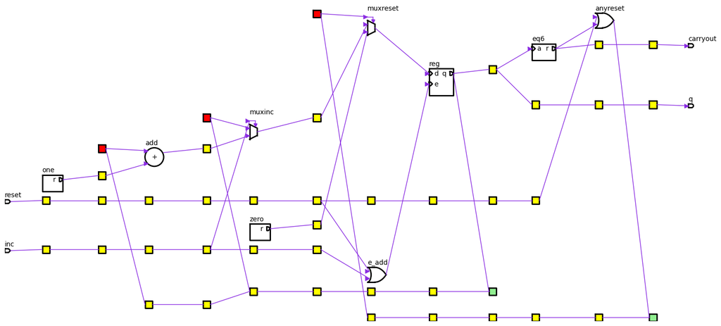

```python
sch.trackAssignment()

for i in range(len(sch.channels)):
    print()
    print('Channel', i)
    channel = sch.channels[i]
    track = channel['track']

    for wire in track.keys():
        print('  track')
        nets = track[wire]['nets']

        for net in nets:
            source = net.source
            sourcePort = net.sourcePort
            sink = net.sink
            sinkPort = net.sinkPort

            if (sourcePort is not None):
                sourcePort = f'[{sourcePort.name}]'
            else:
                sourcePort = ''

            if (sinkPort is not None):
                sinkPort = f'[{sinkPort.name}]'
            else:
                sinkPort = ''

            print('    ',source.name, sourcePort, '-->', sink.name, sinkPort)


sch.replaceAsColRow()
sch.routeNets(mode='direct')
sch.createRender()
sch.drawAll(debug=True)
```

### Route Nets

```
<py4hw.schematic.MatplotlibRender at 0x13f2b55c3d0>
```

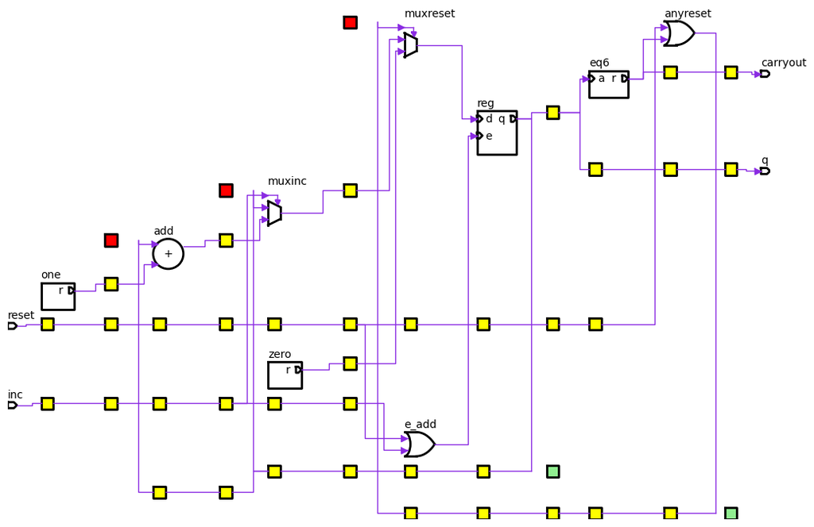

```python
sch.CELL_MARGIN_HORIZONTAL = 5
sch.replaceAsColRow()
sch.routeNets(mode='square')
sch.replaceAsColRow()
sch.createRender()
sch.drawAll(debug=True)
```

```python
def shrinkVirtualSymbols(self):
    nr, nc = self.symbol_matrix.shape

    for r in range(nr):
        for c in range(nc):
            sym = self.symbol_matrix[r,c]
            if (sym is None):
                continue

            if isinstance(sym, py4hw.VirtualSymbol):
                sym.w, sym.h = 1,1

sch.replaceAsColRow()
#shrinkVirtualSymbols(sch)
```

```
<py4hw.schematic.MatplotlibRender at 0x13f2bbe5210>
```

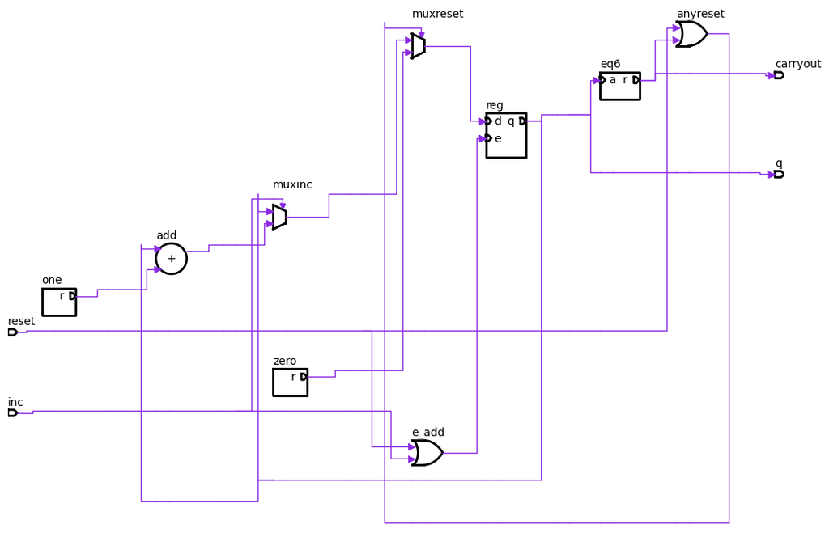

```python
sch.removeArrowsSpecialCases()
sch.createRender()
sch.drawAll(debug=False)
```

### Detect vertical gaps

I think we should find the vertical center of gravity of the graph. Then find vertical gaps and try to compress the graph in the direction of the vertical center of gravity. We should consider chains as a whole object.

For instance, q (and its chain) can be lowered. All the elements have many free cells below.

```python
if (False):
    #print_matrix()

    sch.replaceAsColRow()

    from collections import defaultdict
    source = defaultdict(list)

    for net in sch.getNets():
        c = net.source.c

        source[c].append(net)


    # We move the left elements to match the right ones
    for c in range(nc-1):
        for net in source[c]:
            #print(f'[{net.source.r}]', net.source.name, '-->' , f'[{net.sink.r}]', net.sink.name)
            #print(sch.symbol_matrix[net.source.r, net.source.c])

            # check if left object can move towards right
            left_dst = net.sink.r - net.source.r
            left_inc = np.sign(left_dst)

            #print('move', left_dst, left_inc)
            lr = net.source.r

            doRun = True
            while (doRun and lr != net.sink.r):
                lr += left_inc
                #print('lr', lr, net.source.c, sch.symbol_matrix[lr, net.source.c])
                doRun = sch.symbol_matrix[lr, net.source.c] == None

                if (doRun):
                    sch.symbol_matrix[lr-left_inc, net.source.c] = None
                    sch.symbol_matrix[lr, net.source.c] = net.source
                    #print('moving to', lr)

    # We move the right elements to match the left ones

    for c in range(nc-2, -1, -1):
        for net in source[c]:

            # check if right object can move towards the left one
            right_dst = net.source.r - net.sink.r
            right_inc = np.sign(right_dst)


            rr = net.sink.r

            doRun = True
            while (doRun and rr != net.source.r):
                rr += right_inc

                doRun = sch.symbol_matrix[rr, net.sink.c] == None

                if (doRun):
                    sch.symbol_matrix[rr-right_inc, net.sink.c] = None
                    sch.symbol_matrix[rr, net.sink.c] = net.sink
```

```python
def compactVertically(self):
    """Remove empty rows within each column after alignment."""
    nr, nc = self.symbol_matrix.shape

    for c in range(nc):
        # Collect all symbols in this column in row order
        symbols_in_col = []
        for r in range(nr):
            if self.symbol_matrix[r, c] is not None:
                symbols_in_col.append((r, self.symbol_matrix[r, c]))

        # Clear the column
        for r in range(nr):
            self.symbol_matrix[r, c] = None

        # Repack from the top, removing gaps
        for new_r, (old_r, symbol) in enumerate(symbols_in_col):
            self.symbol_matrix[new_r, c] = symbol
            symbol.r = new_r


if (False):
    compactVertically(sch)
    sch.replaceAsColRow()
    sch.routeNets(mode='square')
    sch.replaceAsColRow()
    sch.createRender()
    sch.drawAll(debug=False)
```

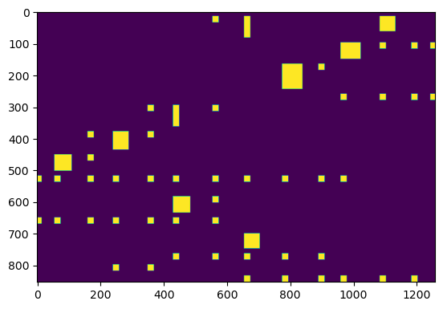

```python
plt.imshow(sch.getOccupancyGrid())
plt.show()
```